# *Bop or Flop? A Semi-Supervised Approach to Predicting Song Popularity via Spotify Audio Features*

## Introduction

**Case Study**  
An up-and-coming music record label receives large numbers of demo submissions from artists on a regular basis. Executives at the company are seeking a data-driven solution which automates the demo selection process; focused primarily on maximising commercial success and profitability for the record label.

**Aims, Objectives & Dataset Chosen**  
The task objective is to create a classification model predicting the likelihood of a song being a commercial success, based on features known to audio tracks. This project uses *Spotify Audio Features* containing 0-100 values for a number of song characteristics including 'loudness', 'instrumentalness', 'speechiness' & 'energy', amongst other features. Pandya (2023) collated 114,000 songs from the Spotify API; the chosen dataset for this task.

The key milestones for the project are:

- (Technical) Leverage as many audio features as possible, using feature engineering to give deeper insight into potentially unseen song groupings.
- (Technical) Train a classification model to predict binary outcome of popularity, based on an acceptable popularity threshold.
- (Business) Quantify the financial risk of either releasing a demo from an artist that does not achieve commercial success (also known as a 'flop'), or failing entirely to sign a successful song. This is best represented by the confusion matrix of the final classification model:
  - *True Positive*: The demo is successful by both prediction and reality (**+2**).
  - *False Positive*: The demo is not successful in reality, but predicted so (**-1**).
  - *True Negative*: The demo is unsuccessful by both prediction and reality (**+0**).
  - *False Negative*: The demo is successful in reality, but is not predicted so (**-2**).

### Code Preamble

```python
import pandas as pd
import matplotlib.pyplot as plt
import numpy as np
from mpl_toolkits.mplot3d import Axes3D
from sklearn.model_selection import train_test_split, GridSearchCV, cross_val_score, StratifiedKFold, RandomizedSearchCV
from sklearn.preprocessing import OneHotEncoder, StandardScaler
from sklearn.cluster import KMeans, MiniBatchKMeans
from sklearn.metrics import silhouette_score, classification_report, roc_auc_score, confusion_matrix, ConfusionMatrixDisplay
from sklearn.decomposition import PCA
from sklearn.ensemble import RandomForestClassifier
import warnings
warnings.filterwarnings("ignore")

# Importing the Spotify dataset
spotify = pd.read_csv('spotify_tracks.csv')
```

## Data Preparation

### Defining Popularity

```python
total_rows = len(spotify)
thresholds = [90, 80, 75, 70]
popularity = []

for score in thresholds:
    popular = spotify[spotify['popularity'] >= score]
    not_popular = spotify[spotify['popularity'] < score]
    popular_pct = round(len(popular) / total_rows *100,2)
    not_popular_pct = round(len(not_popular) / total_rows *100,2)

    popularity.append({
        'Popularity Threshold': f">= {score}",
        'Popular (%)': popular_pct,
        'Not Popular (%)': not_popular_pct
    })

summary = pd.DataFrame(popularity)
print(summary)

# 75 is an appropriate score, representing top ~2.5% of songs
```

```
  Popularity Threshold  Popular (%)  Not Popular (%)
0                >= 90         0.09            99.91
1                >= 80         1.05            98.95
2                >= 75         2.48            97.52
3                >= 70         4.80            95.20
```

The intention is to build a binary classification model, so an appropriate `popularity` score threshold, $p \in [0,100]$ must be chosen. It is important to find a midpoint between maximal commercial success and class size, therefore a value of 90 is not ideal as this threshold represents only the top 0.09% of songs, causing extreme class imbalance. A value of 75 is much more optimal.

### Ensuring Acceptable Data Quality

```python
# Data Cleaning

# Completing all data processing steps that can be done pre-split
# All data cleaning that doesn't affect data leakage
def pre_split_processing(dataset):
    # Remove irrelevant fields, rows with any nulls, and dupicate rows
    v1 = dataset.drop(['Unnamed: 0','artists',
                       'album_name','track_name'],axis=1).dropna().drop_duplicates()

    # Drop the irrelevant field 'track_id', but after duplicate row check
    v2 = v1.drop(['track_id'],axis=1)

    # Create a target variable for classification
    v2['is_popular'] = v2['popularity'].apply(lambda x: 1 if x >= 75 else 0)
    v2 = v2.drop(['popularity'], axis=1)

    # Convert boolean fields to numeric
    v2 = v2.apply(lambda col: col.astype(int) if col.dtype == 'bool' else col)

    return v2

# Completing the test-train-split
# Required for any prediction/classification (aka. supervised learning)
# Not always necessary for unsupervised learning
def data_split(dataset):
    # Eventual model features
    X = dataset.drop(['is_popular'],axis=1)
    y = dataset['is_popular']

    # test_size = 0.2 ensures an 80:20 train:test ratio
    # stratify = y ensures equal distribution of the target in both datasets
    # random_state = 7 is a seed to ensure the sample sizes are randomly distributed & retrievable
    X_train, X_test, y_train, y_test = train_test_split(X, y, stratify = y, test_size = 0.2, random_state = 7)

    return X_train, X_test, y_train, y_test
```

Before exploring and/or transforming the dataset, the data must be of an acceptable standard. Wang and Strong (1996) propose a data quality framework consisting of 4 categories, intrinsic, contextual, representational and accessibility data quality. The dimensions in each category build a comprehensive foundation for acceptable data creation, storage and usage. To prepare data for modelling a number of data quality dimensions should be considered, some of which are addressed by the data preparation tasks above.

- **Accessibility & Reputation**: The dataset compiled and published by Pandya (2023) is publicly available, and gathered from a reputable source (Spotify API).
- **Relevancy & Timeliness**: The dataset used for modelling is appropriate for this task, and reasonably up-to-date having been compiled in 2023. However, some fields are not necessary for popularity prediction and are omitted. This includes `track_id`, however this field is kept temporarily to ensure data uniqueness.
- **Completeness**: Every column in the dataset must contain complete data, so any row entry containing at least one null value is omitted.
- **Consistency & Uniqueness**: There should be no redundancy in the data, so any duplicate rows are omitted (This is why the field `track_id` is required).

### Collinearity

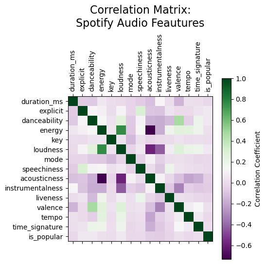

```python
spotify_clean_v1 = pre_split_processing(spotify)

# Checking for collinearity before splitting
correlation = spotify_clean_v1.select_dtypes(include=['float64','int64']).corr()
col_labels = correlation.columns

matrix = plt.matshow(correlation, cmap = 'PRGn')
plt.colorbar(matrix, label = 'Correlation Coefficient')
plt.xticks(ticks = np.arange(len(col_labels)), labels = col_labels, rotation=90)
plt.yticks(ticks = np.arange(len(col_labels)), labels = col_labels,)
plt.title('Correlation Matrix:\nSpotify Audio Feautures', pad = 10, fontsize = 16)

# Removing highly correlated features to help fix multicollinearity
spotify_clean_v2 = spotify_clean_v1.drop(['acousticness','loudness'],axis=1)
```

The first exploration of the dataset addresses collinearity. The correlation matrix above shows many strong links between different features, indicating multicollinearity. Specifically:

- `acousticness` has a strong negative correlation with both `energy` and `loudness`
- `loudness` has a strong positive correlation with `energy`, and a moderately negative correlation with `instrumentalness`

To eliminate multicollinearity in the data, features `acousticness` and `loudness` are omitted.

### Class Imbalance

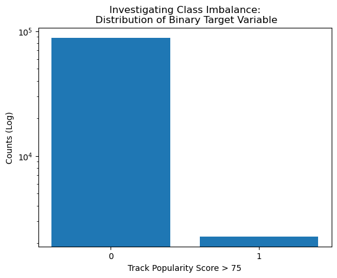

```python
training_features = data_split(spotify_clean_v2)[0]
training_target = data_split(spotify_clean_v2)[2]
test_features = data_split(spotify_clean_v2)[1]
test_target = data_split(spotify_clean_v2)[3]

# Checking visually for class imbalance
target_counts = training_target.value_counts()
plt.bar(target_counts.index,target_counts.values)
plt.xlabel('Track Popularity Score > 75')
plt.ylabel('Counts (Log)')
plt.title('Investigating Class Imbalance:\n Distribution of Binary Target Variable')
plt.xticks([0,1])
plt.yscale('log') # Using logarithmic scale to visually see both categories
```

Given this is a binary classification problem and a disproportionately high popularity score is chosen, it is no surprise to see class imbalance. There are many approaches that could address class imbalance, such as creating synthetic data points for the minority class `is_popular = 1` (techniques such as *SMOTE*), or reducing the number of data points in the majority class. To preserve as much relevance in the data, class imbalance will be handled during modelling (e.g. `class_weight = 'balanced'` for Random Forest)

### Data Transformations

```python
# Encoding
# Ensures categorical variable track_genre can be handled numerically
# encoder = OneHotEncoder(sparse_output=False, handle_unknown='ignore')
#    Note: Not used due to exploding model features

# Frequency Encoding
# For the training data
genre_frequency_tr = training_features['track_genre'].value_counts()
training_features['genre_freq'] = training_features['track_genre'].map(genre_frequency_tr)
training_features = training_features.drop(['track_genre'], axis = 1)

# For the training data
genre_frequency_te = test_features['track_genre'].value_counts()
test_features['genre_freq'] = test_features['track_genre'].map(genre_frequency_te)
test_features = test_features.drop(['track_genre'], axis = 1)
```

```python
# Scaling

# Ensures features with different ranges do not dominate (duration_ms is a good example)
# All features now normalised between [-1,1] (mean = 0 & sd = 1)

# For the training data
scaler = StandardScaler()
training_features = pd.DataFrame(scaler.fit_transform(training_features),
                                 columns = training_features.columns,
                                 index = training_features.index)

# For the test data
test_features = pd.DataFrame(scaler.transform(test_features),
                                 columns = test_features.columns,
                                 index = test_features.index)
```

To avoid data leakage, some pre-processing transformations must be completed after splitting the data into train and test sets. Scaling and encoding are both done post-split, to eliminate the risk of models inheriting bias and/or losing relevancy.

## Unsupervised Learning: K-Means Clustering

### Optimisation

```
The training dataset has 13 columns and 90840 rows.
```

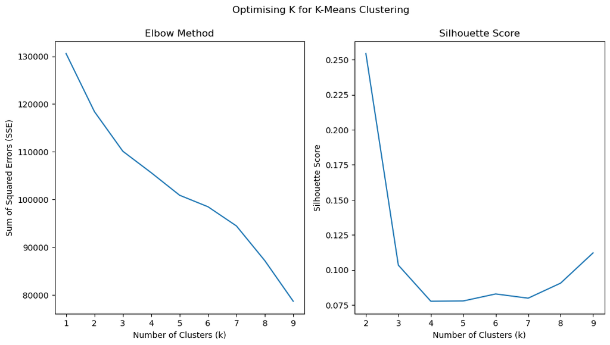

```python
# Optimising K-Means
# Elbow Method: Cluster Size vs. SSE (Sum of Squared Errors)
# Silhouette: Cluster Size vs. Average distance from nearest neighbour
#   Note: Does not work for k = 1 based on definition

# K-Means can be computationally heavy, use a sample of the training set
# Using Mini-Batch K-Means for computational efficiency

print(f"The training dataset has {len(training_features.columns)} columns and {len(training_features)} rows.")

sse = []
silhouette = []
k_test = range(1,10)
training_features_reduced = training_features.sample(10000, random_state = 7)

for k in k_test:
    kmeans = MiniBatchKMeans(n_clusters = k, random_state = 10, batch_size = 1000)
    preds = kmeans.fit_predict(training_features_reduced)
    # Elbow Method: SSE is called inertia in sklean package
    sse.append(kmeans.inertia_)
    if k > 1:
        # Silhouette Scores
        s_score = silhouette_score(training_features_reduced,preds)
        silhouette.append(s_score)

fig,(ax1,ax2) = plt.subplots(1,2, figsize = (12,6))
fig.suptitle('Optimising K for K-Means Clustering')

ax1.plot(k_test, sse)
ax1.set_xlabel('Number of Clusters (k)')
ax1.set_ylabel('Sum of Squared Errors (SSE)')
ax1.set_title('Elbow Method')

ax2.plot(range(2,10), silhouette)
ax2.set_xlabel('Number of Clusters (k)')
ax2.set_ylabel('Silhouette Score')
ax2.set_title('Silhouette Score')
```

Given the dataset is large, there is significant class imbalance, and there is not an abundance of audio features (13 inputs), clustering provides several 'boosts'. It can uncover hidden structure in the data, including non-linear patters, and subtly boost class imbalance. Here, K-Means clustering is used as a form of *feature engineering*, enriching the dataset with more insight before classification. To improve computational efficiency, Mini-Batch K-Means is used on a reduced sample of the training set. While this may have a marginal impact on performance compared to clustering on the full dataset, the trade-off is acceptable given the scalability benefits.

In order to determine the ideal cluster size, two performance metrics are evaluated:

1. **Elbow Method**: Cluster size vs. Sum of Squared Errors (SSE). Lower scores are better, with the 'elbow point' usually considered an optimal cluster size. This signifies a lack of significant decrease in cluster variance for greater k values. There is a slight elbow at k=5 although SSE does continue to decrease with more clusters.
2. **Silhouette Score**: Cluster size vs. Average Silhouette Score; the average separation of each data point in a cluster from its nearest neighbour cluster. Higher scores are better, with k=2 showing clear optimality.

With a lack of a strong elbow from the SSE curve, the Silhouette Score is favoured.

### Model Fitting

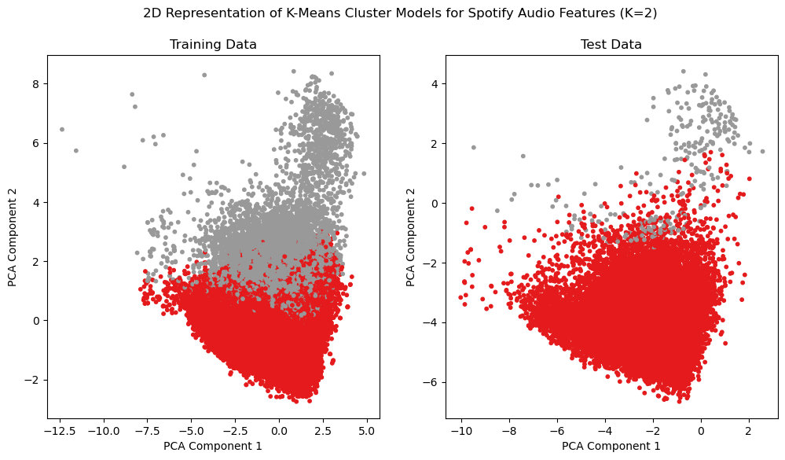

```python
# K-Means struggling to see clear natural structure from results
# For the pupose of seeing clear, distinct clusters, prioritise silhouette score
#   This will avoid overfitting as much as possible

# K-Means Model
k_model = MiniBatchKMeans(n_clusters = 2, random_state = 10, batch_size = 1000)

# Preparation for visualisation
# Flattening model features to 2D using PCA
pca = PCA(n_components = 2, random_state = 10)

# For the training data
preds_train = k_model.fit_predict(training_features)
pca_train = pca.fit_transform(training_features)

# For the test data
preds_test = k_model.predict(test_features)
pca_test = pca.transform(test_features)

fig,(ax1,ax2) = plt.subplots(1,2, figsize = (12,6))
fig.suptitle('2D Representation of K-Means Cluster Models for Spotify Audio Features (K=2)')

ax1.scatter(pca_train[:,0], pca_train[:,1], c=preds_train, cmap='Set1', s=10)
ax1.set_xlabel('PCA Component 1')
ax1.set_ylabel('PCA Component 2')
ax1.set_title('Training Data')

ax2.scatter(pca_test[:,0], pca_test[:,1], c=preds_test, cmap='Set1', s=10)
ax2.set_xlabel('PCA Component 1')
ax2.set_ylabel('PCA Component 2')
ax2.set_title('Test Data')
```

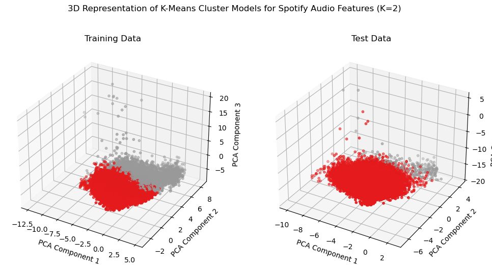

```python
# Alternate visualisation for better cluster understanding
# Flattening model features to 3D using PCA
pca_3d = PCA(n_components = 3, random_state = 10)

# For the training data
pca_train_3d = pca_3d.fit_transform(training_features)

# For the test data
pca_test_3d = pca_3d.transform(test_features)

fig = plt.figure(figsize = (12,6))
fig.suptitle('3D Representation of K-Means Cluster Models for Spotify Audio Features (K=2)')

ax1 = fig.add_subplot(1, 2, 1, projection='3d')
ax1.scatter(pca_train_3d[:, 0], pca_train_3d[:, 1], pca_train_3d[:, 2],
            c=preds_train, cmap='Set1', s=10)
ax1.set_title('Training Data')
ax1.set_xlabel('PCA Component 1')
ax1.set_ylabel('PCA Component 2')
ax1.set_zlabel('PCA Component 3')

# Test plot
ax2 = fig.add_subplot(1, 2, 2, projection='3d')
ax2.scatter(pca_test_3d[:, 0], pca_test_3d[:, 1], pca_test_3d[:, 2],
            c=preds_test, cmap='Set1', s=10)
ax2.set_title('Test Data')
ax2.set_xlabel('PCA Component 1')
ax2.set_ylabel('PCA Component 2')
ax2.set_zlabel('PCA Component 3')
```

The dataset has many dimensions, which can make clusters difficult to distinguish. Here, the `sklearn` PCA library is used for dimensionality reduction, representing the clusters both 2 and 3-dimensionally.

### Feature Engineering

```python
# Adding clusters as an additional model feature
# Can help combat class imbalance, feature bias & anomalous data

training_features_enhanced = training_features.copy()
training_features_enhanced['cluster'] = preds_train

test_features_enhanced = test_features.copy()
test_features_enhanced['cluster'] = preds_test
```

## Supervised Learning: Random Forest Classification

### Optimisation

```python
# Baseline Model
randomforest = RandomForestClassifier(random_state = 7)
randomforest.fit(training_features_enhanced,training_target)

rf_pred_train = randomforest.predict(training_features_enhanced)
rf_pred_test = randomforest.predict(test_features_enhanced)

print('Classification Report (Training Data):\n', classification_report(training_target,rf_pred_train))
print('Classification Report (Test Data):\n', classification_report(test_target,rf_pred_test))

# Unfortunately shows the extent of class imbalance issue
# Leading to extreme overfitting, and near total dominance of majority class in test data
```

```
Classification Report (Training Data):
               precision    recall  f1-score   support

           0       1.00      1.00      1.00     88577
           1       0.99      0.92      0.95      2263

    accuracy                           1.00     90840
   macro avg       0.99      0.96      0.98     90840
weighted avg       1.00      1.00      1.00     90840

Classification Report (Test Data):
               precision    recall  f1-score   support

           0       0.98      1.00      0.99     22144
           1       0.92      0.02      0.04       566

    accuracy                           0.98     22710
   macro avg       0.95      0.51      0.51     22710
weighted avg       0.97      0.98      0.96     22710
```

```
Baseline financial payoff: -1085
```

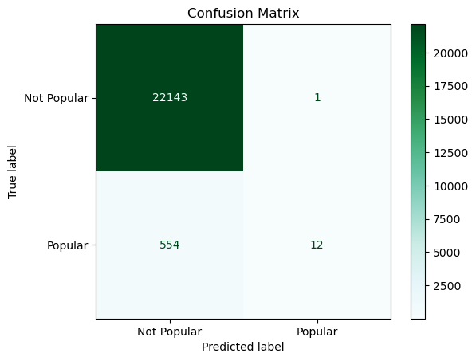

```python
initial_confusion = confusion_matrix(test_target, rf_pred_test)
matrix = ConfusionMatrixDisplay(confusion_matrix = initial_confusion, display_labels=['Not Popular', 'Popular'])
matrix.plot(cmap = 'BuGn')
plt.title('Confusion Matrix')

true_neg = initial_confusion[0,0]
true_pos = initial_confusion[1,1]
false_neg = initial_confusion[1,0]
false_pos = initial_confusion[0,1]
financial_risk = (0*true_neg)+(2*true_pos)+(-2*false_neg)+(-1*false_pos)
print(f"Baseline financial payoff: {financial_risk}")
```

```python
# Hyperparameter testing
hyperparams = {
    'n_estimators': [100, 300, 500],                    # Number of trees
    'max_depth': [20, 40, None],                        # Max depth of the tree
    'min_samples_split': [2, 5, 10],                    # Min samples required to split node
    'min_samples_leaf': [2, 5, 10],                     # Min samples required per node
    'max_features': ['sqrt', 'log2'],                   # Max features per tree
    'class_weight': ['balanced', 'balanced_subsample'], # Penalise imbalance
    'bootstrap': [True, False]                          # Test bootstrap approach
}

# Taking a sample of training set for computational efficiency
# Final model will be built using whole training set
# Nested CV is too computationally heavy for 14 cols // 90k+ rows
rf_features_sample, _, rf_target_sample, _ = train_test_split(
    training_features_enhanced, training_target, train_size = 10000,
    stratify = training_target, random_state = 7
)

# Nested cross-validation
# Inner CV (tuning hyperparameters)
inner = StratifiedKFold(n_splits = 3, shuffle = True, random_state = 7)

# Outer CV (evaluate model per fold)
outer = StratifiedKFold(n_splits = 3, shuffle = True, random_state = 7)

# Run RF iterations under all hyperparameters
# Using RandomizedSearchCV for computational efficiency
rs = RandomizedSearchCV(estimator = randomforest, param_distributions = hyperparams,
                        n_iter = 50, cv = inner, scoring = 'f1', n_jobs = -1, random_state = 7)
nest_scoring = cross_val_score(rs, rf_features_sample, rf_target_sample,
                               cv = outer, scoring = 'f1')

print(f"Individual F1-Scores:", nest_scoring)
print(f"Nested CV F1-Score: {round(np.mean(nest_scoring),4)} +/- {round(np.std(nest_scoring),4)}")
```

```
Individual F1-Scores: [0.11594203 0.12865497 0.17177914]
Nested CV F1-Score: 0.1388 +/- 0.0239
```

### Model Fitting

```python
# Fitting to the whole training set
rs.fit(training_features_enhanced, training_target)
print(f"Optimal hyperparameters: {rs.best_params_}")

# Pass optimal parameters into final model
optimal_forest = RandomForestClassifier(**rs.best_params_, random_state = 7)
optimal_forest.fit(training_features_enhanced, training_target)
rf_pred_test = optimal_forest.predict(test_features_enhanced)

print(classification_report(test_target, rf_pred_test))
```

```
Optimal hyperparameters: {'n_estimators': 300, 'min_samples_split': 10, 'min_samples_leaf': 5, 'max_features': 'log2', 'max_depth': None, 'class_weight': 'balanced_subsample', 'bootstrap': False}
              precision    recall  f1-score   support

           0       0.98      1.00      0.99     22144
           1       0.81      0.04      0.07       566

    accuracy                           0.98     22710
   macro avg       0.90      0.52      0.53     22710
weighted avg       0.97      0.98      0.96     22710
```

```
Optimised financial payoff: -1049
Optimised Model - True Positives: 22
Optimised Model - Popular (%): 0.1
Full Dataset Distribution: {'Popularity Threshold': '>= 75', 'Popular (%)': 2.48, 'Not Popular (%)': 97.52}
```

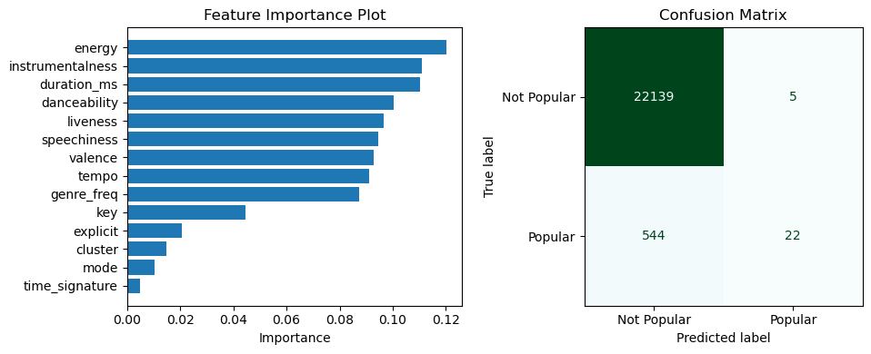

```python
true_neg2 = final_confusion[0,0]
true_pos2 = final_confusion[1,1]
false_neg2 = final_confusion[1,0]
false_pos2 = final_confusion[0,1]
financial_risk2 = (0*true_neg2)+(2*true_pos2)+(-2*false_neg2)+(-1*false_pos2)
print(f"Optimised financial payoff: {financial_risk2}")

fig, axes = plt.subplots(1, 2, figsize = (10, 4))
final_confusion = confusion_matrix(test_target, rf_pred_test)
ConfusionMatrixDisplay(confusion_matrix = final_confusion, display_labels=['Not Popular', 'Popular']).plot(
    ax = axes[1], cmap = 'BuGn', colorbar = False)
axes[1].set_title('Confusion Matrix')

importance = optimal_forest.feature_importances_
features = training_features_enhanced.columns
forest_importances = pd.Series(importance, index=features).sort_values(ascending=True)
axes[0].barh(forest_importances.index, forest_importances.values)
axes[0].set_title('Feature Importance Plot')
axes[0].set_xlabel('Importance')
plt.tight_layout()

print(f"Optimised Model - True Positives: {true_pos2}\nOptimised Model - Popular (%): {
            round(true_pos2/len(test_target)*100,2)}\nFull Dataset Distribution: {popularity[2]} ")
```

## Conclusion

### Interpretation of Results

**Technical Highlights**  
The Random Forest model showed marginal improvements after tuning, correctly identifying 10 more tracks than the initial 'baseline' model. However, the severity of class imbalance prevented the model from being able to significantly distinguish between song popularity. The classification report highlights this. There is high precision, with the model correctly predicting popular songs ~81% of the time, however it only identifies ~4% of known popular tracks in the data; given the model features it cannot accurately decipher most songs labelled as popular. Essentially, the model learned to minimise loss by predicting `popular=0` for almost all data points, as popular songs are so rare that never predicting `popular=1` would have a minimal affect on model accuracy.

Whilst the clustering approach identified some structure in the data, the model features that were leveraged had minimal impact on the classification task. The feature importance plot for the optimised Random Forest model showed that out of all 14 model features, the `cluster` feature ranked as the 3rd least important feature for deciding whether a song is popular.

**Business Analysis**  
The recommendation is that in its current state, the model should not be deployed as a suitably accurate popularity predictor. Blindly following the predicition of the model is highly likely to result in a net loss in revenue. To demonstrate using a confusion matrix:

- True positives are predictions which are likely to benefit the case study objectives. Given an arbitrary cost for releasing a track, the assumption is true positives will double commercial revenue.
- True negatives are indifferent to the case study objective. The decision to not allocate cost to releasing a song which is not popular has no impact on the business.
- False positives and false negatives reflect poorly on the case study objective. For false positives, an arbitrary cost is allocated to releasing a track predicted to be popular, but the cost does not yield income. False negatives are missed opportunites to yield the same levels of profit gained from true positives.

Out of 22,710 observations in this data, there were 22 true positives (22 x 2), 5 false positives (5 x -1), 544 false negatives (544 x -2) and 22,139 true negatives (22,139 x 0). Assuming each song cost £1 GBP to release, of the song chosen to release the net profit would be (22 x 2) - (5 x -1) = £39 GBP, however as a direct result of the model there is (544 x 2) = £1,088 GBP of missed opportunities for profit.

### Self-Reflection & Future Work

There is potential for this classification model to serve real-life purpose in song popularity predection, however it currently has some caveats to address moving forward:

- Class imbalance must be addressed robustly to avoid the level of overfitting seen in the model. There are a number of potential approaches:
  - Consider lowering the populatity score threshold, or enrich the data with other popularity-based insights (e.g. number of streams) as an alternative.
  - Balance the dataset by adding and/or removing data from each class (e.g. undersampling the number of 'non-popular' songs, and/or synthetically creating more 'popular' songs).
- Given it did not enrich the data as well as intended, consider removing the clustering approach and use other binary classification models for comparison with Random Forest (e.g. Logistic Regression).

There were also some issues with computational efficiency which required a change in approach. If this project were brought forward it would be preferred to run this analysis in an environment that can effectively handle big data processing:

- The ecoding of `track_genre` initially used one-hot-encoding, but this was abandoned for frequency encoding due to exploding the number of columns in the dataset.
- Both modelling techniques struggled with the size of the training dataset, so adjustments were made. For clustering, the sample size was reduced and Mini-Batch K-Means utilised over K-Means. For Random Forest, there were too many permutations when considering cross-validation and all hyperparameters, so nested cross-validation used Randomised Search over Grid Search to limit the number of iterations.

## References

Pandya, M. 2023. Spotify Tracks Dataset. *Hugging Face*. [Online]. [Accessed 10 June 2025]. Available from: https://huggingface.co/datasets/maharshipandya/spotify-tracks-dataset

Wang, R.Y. and Strong, D.M. 1996. Beyond Accuracy: What Data Quality Means to Data Consumers. *Journal of management information systems*. [Online]. **12**(4), pp.5-33. [Accessed 17 June 2025]. Available from: https://doi.org/10.1080/07421222.1996.11518099